# Importing and Processing CSV Files

Marc Los Huertos

12/6/2016

## Importing CSV Files

First, we will import the CSV file. In most cases, we don’t need to preprocess the csv files.

```r
# Importing Scripts

file = "/home/CAMPUS/fcl02013/Climate_Change_Narratives/Frank/POfairplex.csv"

import = read.csv(file)
```

## Checking the Data

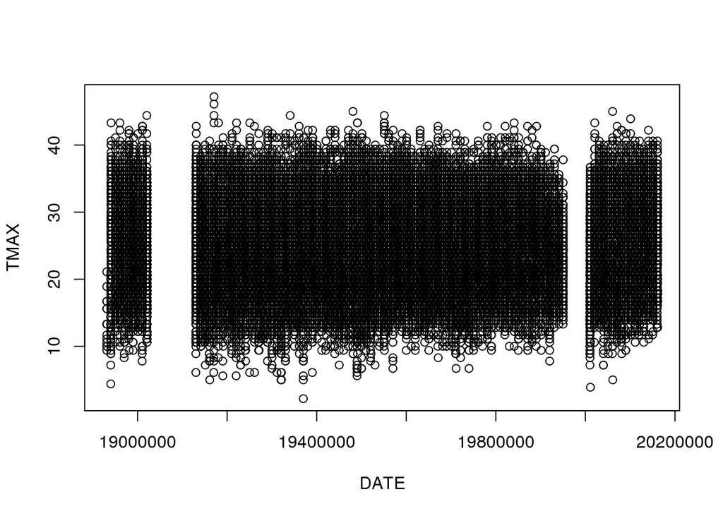

```r
plot(TMAX~DATE, import)
```

```r
import$TMAX[import$TMAX==-9999] = NA
import$TMIN[import$TMIN==-9999] = NA
```

Okay, now we’ll check again, for dates less then Dec. 31, 1913:

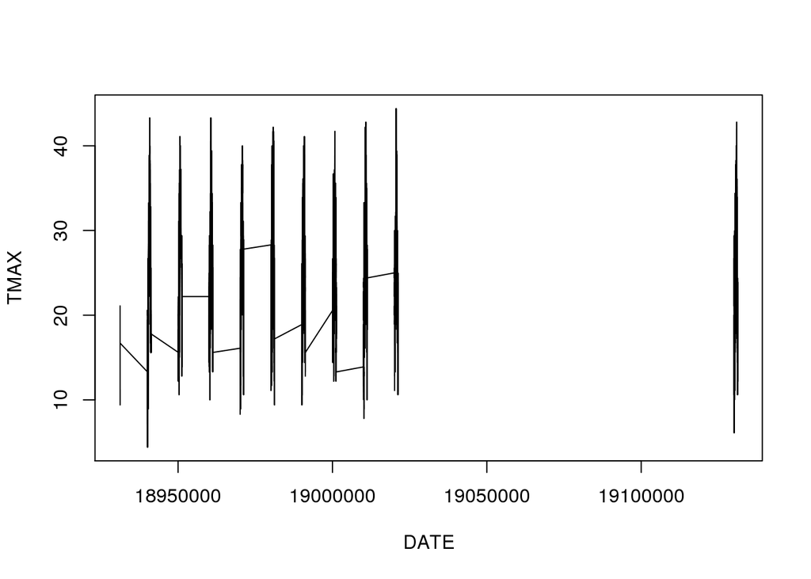

```r
plot(TMAX~DATE, import[import$DATE<19131231,], ty='l')
```

Yikes! What’s wrong? As it turns it the problem is that with how the dates are specified. In particular, the Dec 31 to Jan 1 transition:

19131231 -> 19140101, if you use these as numbers it should be 19131232, 19131232, etc. You see we are missing lots numbers!

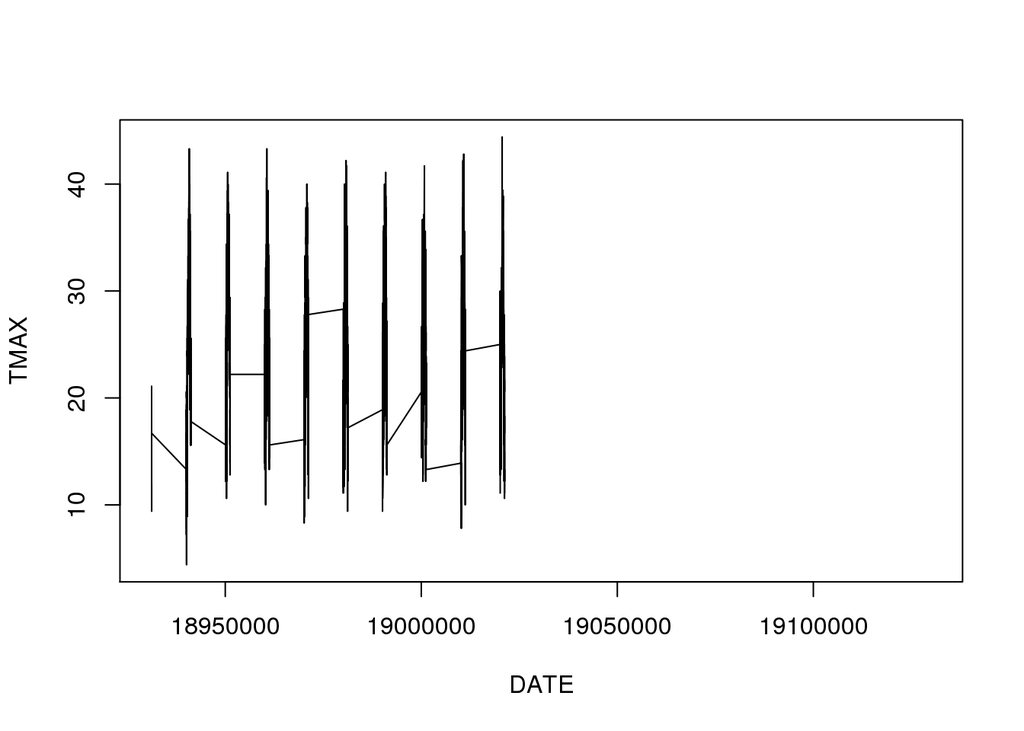

```r
plot(TMAX~DATE, import[import$DATE<19130102,], ty='l')
```

## Fixing the Dates

First, we convert the date a string or character values. Next, we’ll convert the strings to a data format.

```r
strDates <- as.character(import$DATE)
head(strDates)
```

```
## [1] "18931101" "18931102" "18931103" "18931104" "18931105" "18931106"
```

```r
import$NewDate <- as.Date(strDates, "%Y%m%d")
```

## Checking the New Dates

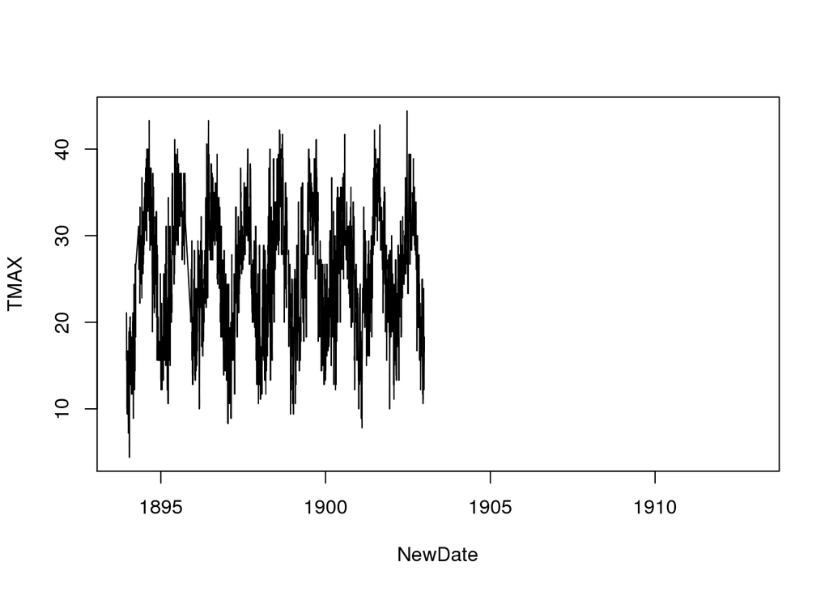

```r
plot(TMAX~NewDate, import[import$DATE<19130102,], ty='l')
```

## Subset Sites

```r
unique(import$STATION_NAME)
```

```
## [1] POMONA FAIRPLEX CA US
## Levels: POMONA FAIRPLEX CA US
```

```r
FAIRPLEX <- subset(import, STATION_NAME=="POMONA FAIRPLEX CA US", select=c(STATION, STATION_NAME, DATE, NewDate, TMIN, TMAX, PRCP))
```

## A new plot

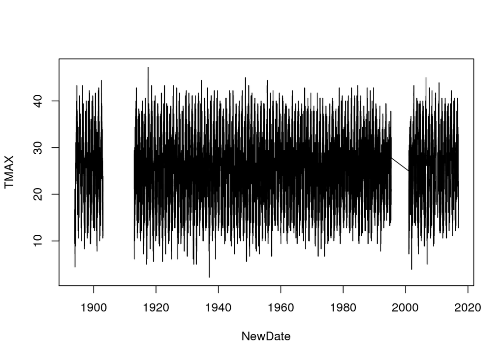

```r
plot(TMAX~NewDate, FAIRPLEX, ty='l')
```

## Evaluating the trend

Creating a linear model and then evaluate the rate (slope).

```r
# Linear Model
FAIRPLEX.lm <- lm(TMAX~NewDate, data=FAIRPLEX)
summary(FAIRPLEX.lm)
```

```
##
## Call:
## lm(formula = TMAX ~ NewDate, data = FAIRPLEX)
##
## Residuals:
##     Min      1Q  Median      3Q     Max
## -23.000  -5.284  -0.109   5.378  22.045
##
## Coefficients:
##              Estimate Std. Error t value Pr(>|t|)
## (Intercept) 2.528e+01  3.780e-02 668.649   <2e-16 ***
## NewDate     6.373e-06  2.902e-06   2.196   0.0281 *
## ---
## Signif. codes:  0 '***' 0.001 '**' 0.01 '*' 0.05 '.' 0.1 ' ' 1
##
## Residual standard error: 6.862 on 38187 degrees of freedom
##   (724 observations deleted due to missingness)
## Multiple R-squared:  0.0001262,  Adjusted R-squared:  0.0001001
## F-statistic: 4.821 on 1 and 38187 DF,  p-value: 0.02811
```

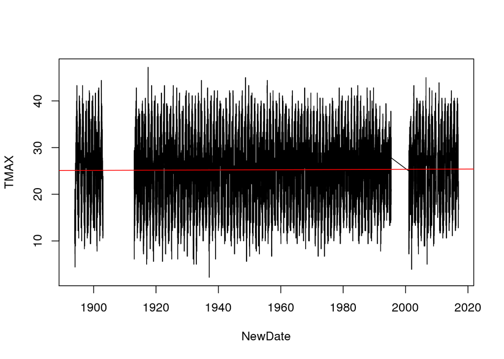

```r
plot(TMAX~NewDate, FAIRPLEX, ty='l')
abline(coef(FAIRPLEX.lm), col='red')
```

## Creating Month and Year Variables

So, let’s figure out how to see how changes happen for individual months.

```r
# Get months
FAIRPLEX$Month = months(FAIRPLEX$NewDate) # Creates problems.
FAIRPLEX$Month = format(as.Date(FAIRPLEX$NewDate), format = "%m")
FAIRPLEX$Year = format(FAIRPLEX$NewDate, format="%Y")
```

### Creating Monthly Means

```r
MonthlyMean = aggregate(TMAX ~ Month + Year, FAIRPLEX, mean)

MonthlyMean$YEAR = as.numeric(MonthlyMean$Year)
MonthlyMean$MONTH = as.numeric(MonthlyMean$Month)


# Frank -- change mean to sd and you'll get standard deviation for each month/year.

MonthlySD = aggregate(TMAX ~ Month + Year, FAIRPLEX, sd)

MonthlySD$YEAR = as.numeric(MonthlySD$Year)
MonthlySD$MONTH = as.numeric(MonthlySD$Month)
MonthlySD$NewDate = MonthlySD$YEAR + (MonthlySD$MONTH - 1)/12

head(MonthlySD)
```

```
##   Month Year     TMAX YEAR MONTH  NewDate
## 1    12 1893 3.520592 1893    12 1893.917
## 2    01 1894 4.196409 1894     1 1894.000
## 3    02 1894 2.802387 1894     2 1894.083
## 4    03 1894 5.569307 1894     3 1894.167
## 5    05 1894 2.233812 1894     5 1894.333
## 6    06 1894 2.859485 1894     6 1894.417
```

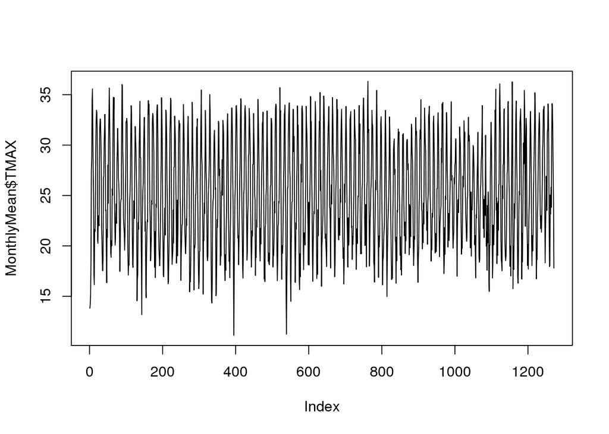

```r
plot(MonthlyMean$TMAX, ty='l')
```

below is sd

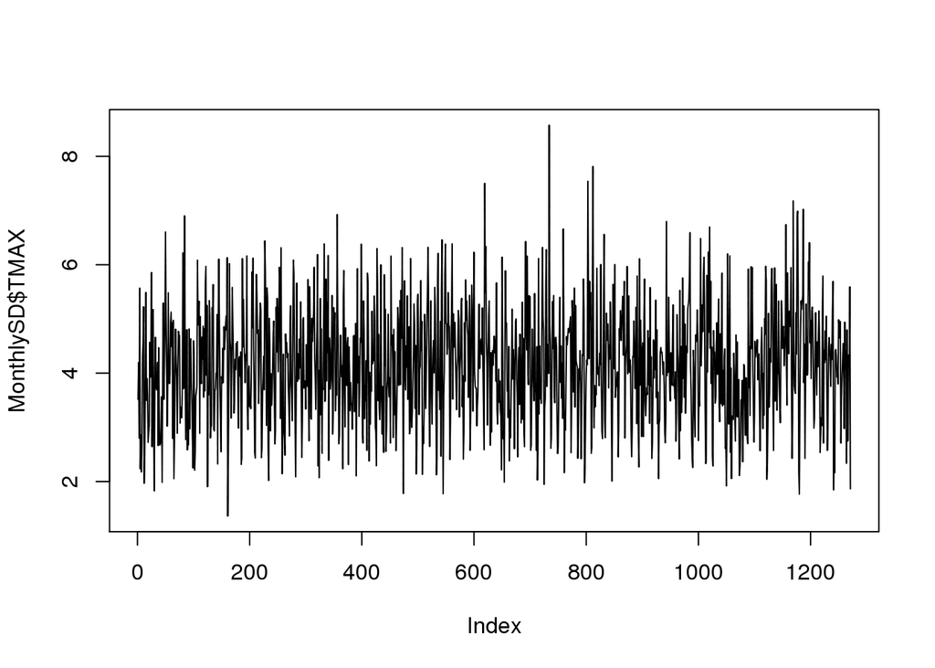

```r
plot(MonthlySD$TMAX, ty='l')
```

```r
plot(TMAX~ NewDate, data=MonthlySD, ty='l')
SD.lm <- lm(TMAX~NewDate, data=MonthlySD)
summary(SD.lm)
```

```
##
## Call:
## lm(formula = TMAX ~ NewDate, data = MonthlySD)
##
## Residuals:
##     Min      1Q  Median      3Q     Max
## -2.7195 -0.7747 -0.0107  0.7294  4.4177
##
## Coefficients:
##              Estimate Std. Error t value Pr(>|t|)
## (Intercept) 1.1188919  1.7618316   0.635   0.5255
## NewDate     0.0015457  0.0009001   1.717   0.0862 .
## ---
## Signif. codes:  0 '***' 0.001 '**' 0.01 '*' 0.05 '.' 0.1 ' ' 1
##
## Residual standard error: 1.071 on 1269 degrees of freedom
## Multiple R-squared:  0.002319,   Adjusted R-squared:  0.001532
## F-statistic: 2.949 on 1 and 1269 DF,  p-value: 0.08617
```

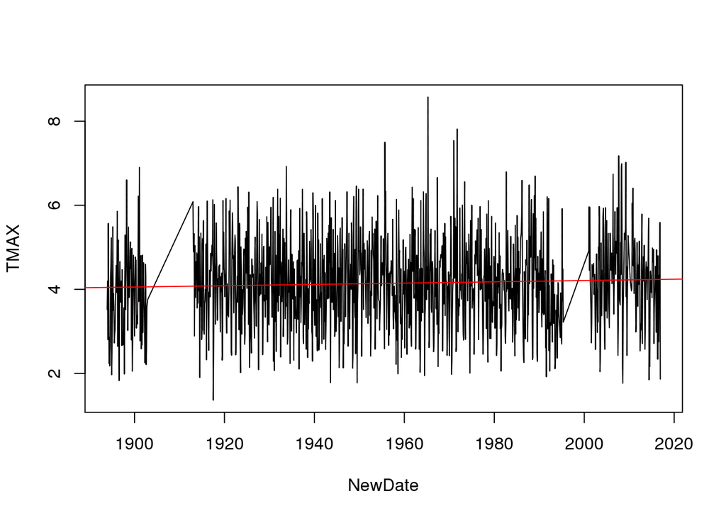

```r
abline(coef(SD.lm), col="red")
```

### Selecting for 1 Month – May

Perhaps, we can get a better handle on this stuff if we analyze for just one month at a time – certainly easier to visualize!

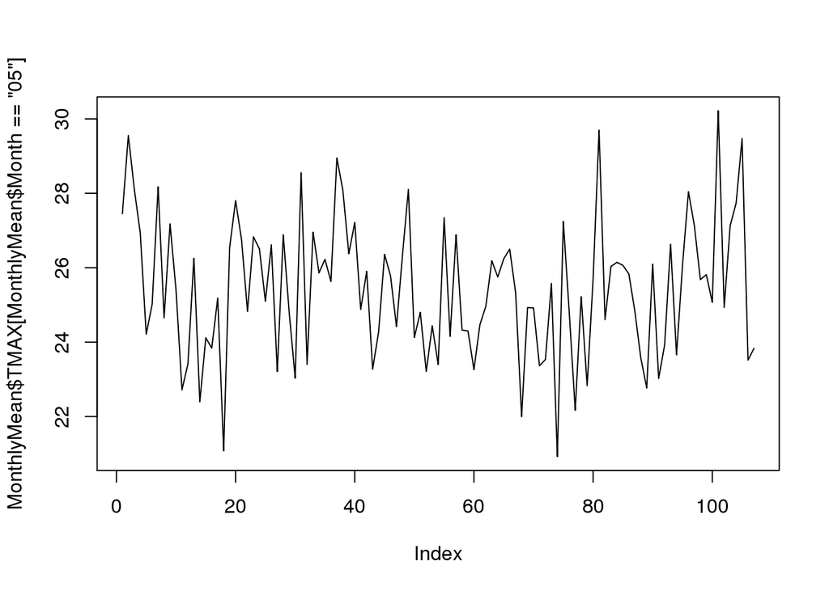

```r
plot(MonthlyMean$TMAX[MonthlyMean$Month=="05"], ty='l')
```

```r
plot(TMAX~YEAR, data=MonthlyMean[MonthlyMean$Month=="05",], ty='l')
May.lm <- lm(TMAX~YEAR, data=MonthlyMean[MonthlyMean$Month=="05",])
summary(May.lm)
```

```
##
## Call:
## lm(formula = TMAX ~ YEAR, data = MonthlyMean[MonthlyMean$Month ==
##     "05", ])
##
## Residuals:
##     Min      1Q  Median      3Q     Max
## -4.4595 -1.3472 -0.0752  1.1701  4.9196
##
## Coefficients:
##              Estimate Std. Error t value Pr(>|t|)
## (Intercept) 30.516475  10.643658   2.867  0.00501 **
## YEAR        -0.002597   0.005438  -0.477  0.63401
## ---
## Signif. codes:  0 '***' 0.001 '**' 0.01 '*' 0.05 '.' 0.1 ' ' 1
##
## Residual standard error: 1.882 on 105 degrees of freedom
## Multiple R-squared:  0.002167,   Adjusted R-squared:  -0.007337
## F-statistic: 0.228 on 1 and 105 DF,  p-value: 0.634
```

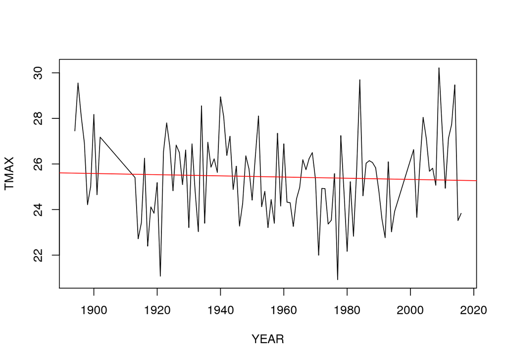

```r
abline(coef(May.lm), col="red")
```

Now, the change is -0.0025967 degress/year or -0.26 degress/100 years (YIKES!) with a probability of 0.634. Although we can’t reject the null hypothesis, it is worrying!

## Next Steps

I think you should evaluate every month and see what happens. You might also consider looking at the TMIN as well. Could be important!

## Lets try Dec

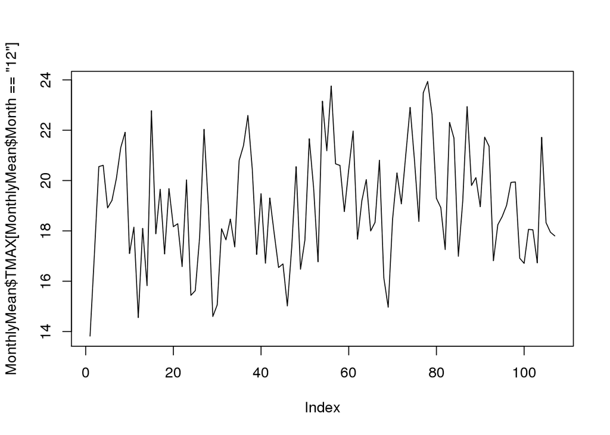

```r
plot(MonthlyMean$TMAX[MonthlyMean$Month=="12"], ty='l')
```

```r
plot(TMAX~YEAR, data=MonthlyMean[MonthlyMean$Month=="12",], ty='l')
Dec.lm <- lm(TMAX~YEAR, data=MonthlyMean[MonthlyMean$Month=="12",])
summary(Dec.lm)
```

```
##
## Call:
## lm(formula = TMAX ~ YEAR, data = MonthlyMean[MonthlyMean$Month ==
##     "12", ])
##
## Residuals:
##     Min      1Q  Median      3Q     Max
## -4.5765 -1.5438 -0.3402  1.6218  4.7248
##
## Coefficients:
##              Estimate Std. Error t value Pr(>|t|)
## (Intercept) -0.147056  12.566051  -0.012    0.991
## YEAR         0.009796   0.006423   1.525    0.130
##
## Residual standard error: 2.247 on 105 degrees of freedom
## Multiple R-squared:  0.02167,    Adjusted R-squared:  0.01235
## F-statistic: 2.326 on 1 and 105 DF,  p-value: 0.1303
```

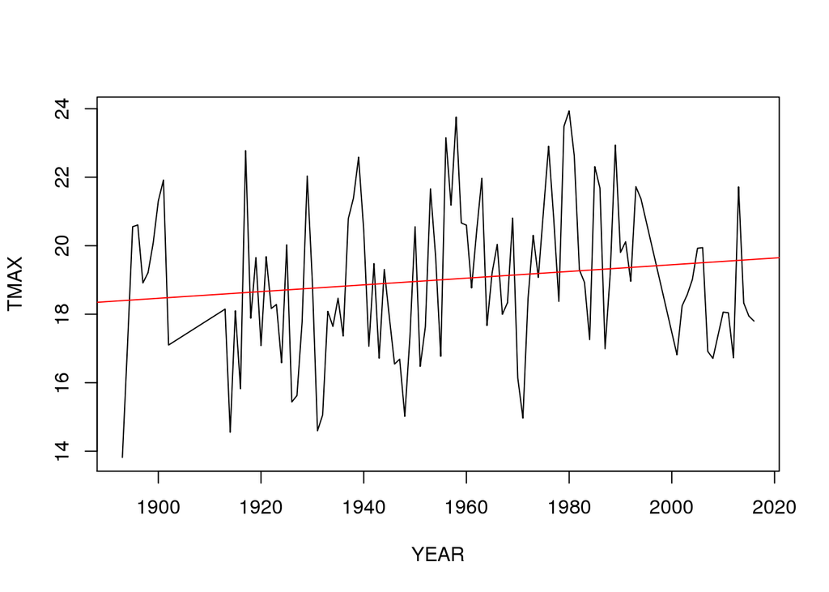

```r
abline(coef(Dec.lm), col="red")
```

## TMIN

1. We create a monthly mean for each month.

```r
MonthlyMeanTMIN = aggregate(TMIN ~ Month + Year, FAIRPLEX, mean)

MonthlyMeanTMIN$YEAR = as.numeric(MonthlyMeanTMIN$Year)
head(MonthlyMeanTMIN)
```

```
##   Month Year       TMIN YEAR
## 1    12 1893  4.1866667 1893
## 2    01 1894  0.5774194 1894
## 3    02 1894  0.7892857 1894
## 4    03 1894  4.7838710 1894
## 5    05 1894 10.4645161 1894
## 6    06 1894 11.3800000 1894
```

2. Now we plot the mins, and again, find tons of scatter.

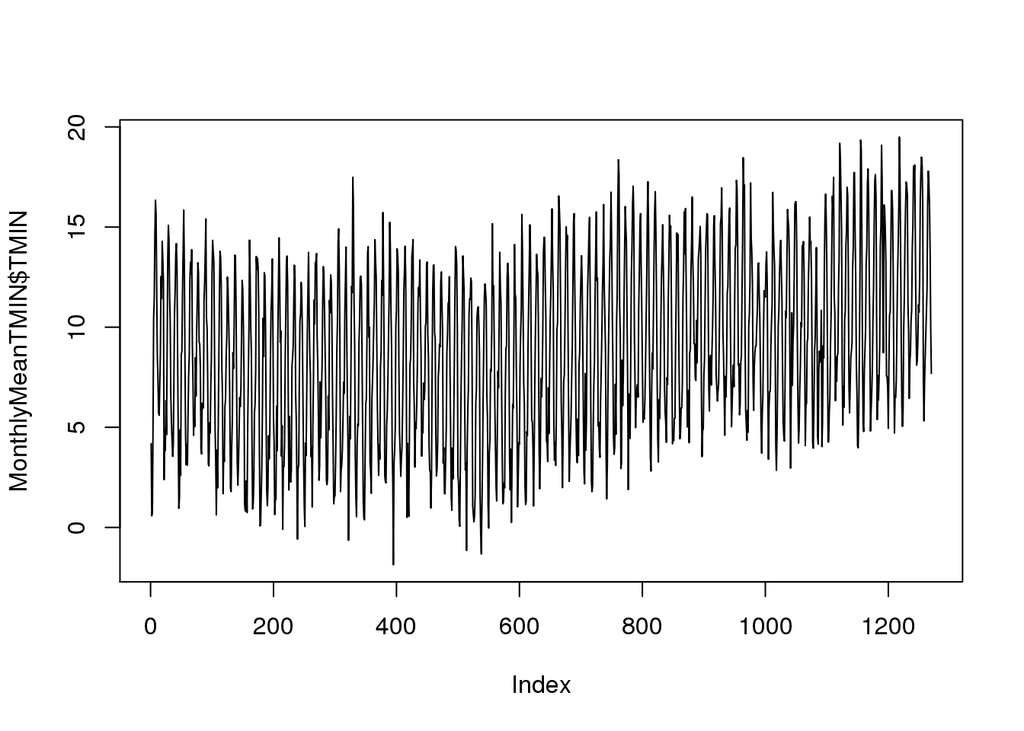

```r
plot(MonthlyMeanTMIN$TMIN, ty='l')
```

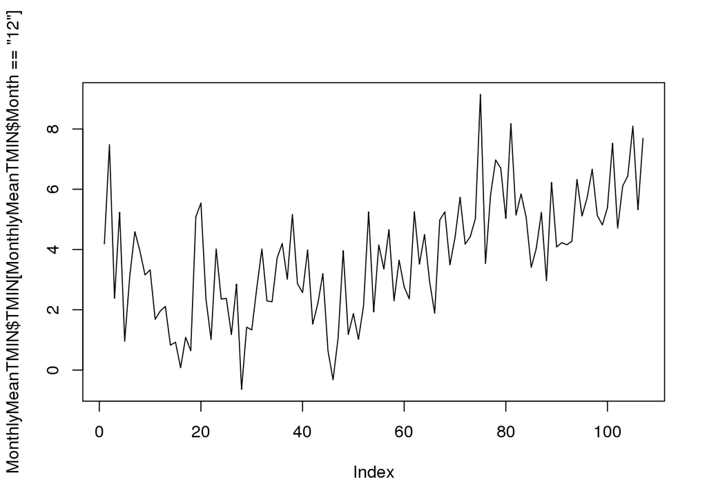

```r
plot(MonthlyMeanTMIN$TMIN[MonthlyMeanTMIN$Month=="12"], ty='l')
```

```r
plot(TMIN~YEAR, data=MonthlyMeanTMIN[MonthlyMeanTMIN$Month=="12",], ty='l')
Dec.lm <- lm(TMIN~YEAR, data=MonthlyMeanTMIN[MonthlyMeanTMIN$Month=="12",])
summary(Dec.lm)
```

```
##
## Call:
## lm(formula = TMIN ~ YEAR, data = MonthlyMeanTMIN[MonthlyMeanTMIN$Month ==
##     "12", ])
##
## Residuals:
##     Min      1Q  Median      3Q     Max
## -3.8288 -1.0831 -0.2372  1.0348  5.7550
##
## Coefficients:
##              Estimate Std. Error t value Pr(>|t|)
## (Intercept) -60.61535    9.33042  -6.497 2.81e-09 ***
## YEAR          0.03291    0.00477   6.901 4.04e-10 ***
## ---
## Signif. codes:  0 '***' 0.001 '**' 0.01 '*' 0.05 '.' 0.1 ' ' 1
##
## Residual standard error: 1.669 on 105 degrees of freedom
## Multiple R-squared:  0.312,  Adjusted R-squared:  0.3055
## F-statistic: 47.63 on 1 and 105 DF,  p-value: 4.043e-10
```

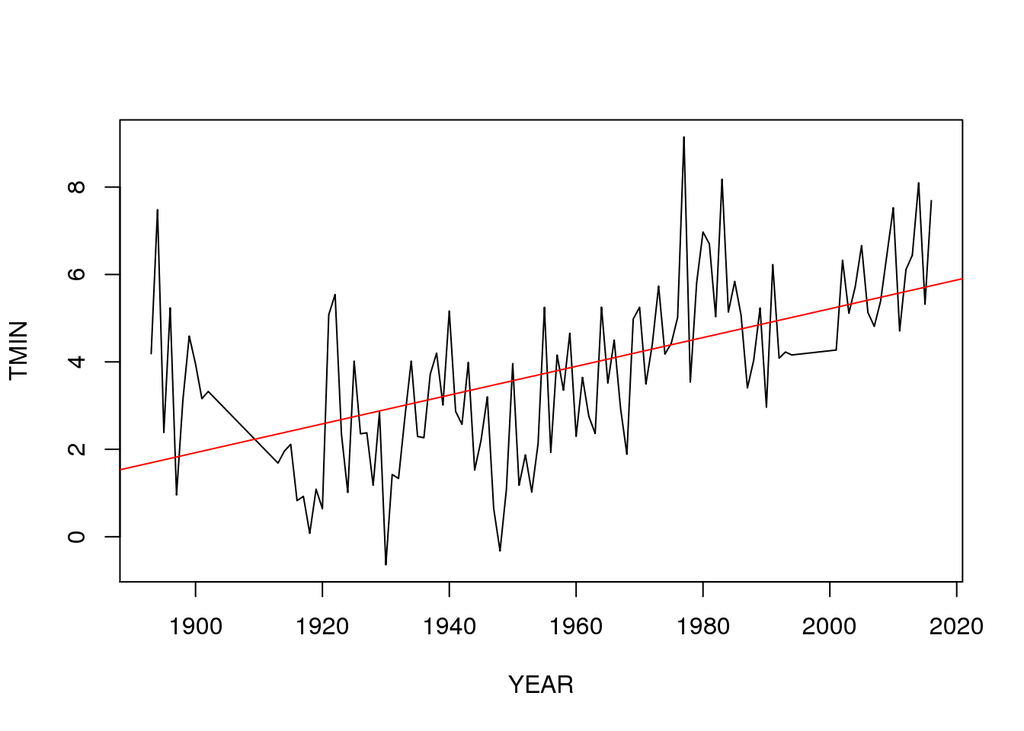

```r
abline(coef(Dec.lm), col="red")
```